# ANOVA for Race

#Chi Square Replication

For example, conduct chi square test for race across 2 time periods. For race - is the count for each racial group different before vs. after Patternizr?

```r
# CLEANING THE DATA


library(tidyverse)
complaints_nonull_demographic <- read_csv("../../data/cleaning/null_demographics_removed.csv")
#complaints_nonull_demographic
```

```r
#CLEAN TO REMOVE UNKNOWN RACE CATEGORY
#remove "U" values in age column assuming they mean unknown - confirm that this is how Jackson did null bootstrap analysis*

race_df <- complaints_nonull_demographic |>
  filter(susp_race != "UNKNOWN")

race_df
```

```
# A tibble: 302,875 × 14
   complaint_date complaint_time precinct_crime report_date crime      x_coord
   <date>         <time>                  <dbl> <chr>       <chr>        <dbl>
 1 2019-12-18     00:01                       9 12/26/2024  RAPE        987496
 2 2017-06-01     12:00                      42 12/19/2024  RAPE       1008690
 3 2014-01-01     00:01                      32 12/19/2024  SEX CRIMES  999433
 4 2015-03-18     12:00                      52 12/18/2024  RAPE       1017478
 5 2014-08-16     00:00                      83 12/17/2024  SEX CRIMES 1007052
 6 2014-12-14     09:00                      68 12/16/2024  SEX CRIMES  977947
 7 2018-06-27     11:00                     121 12/15/2024  RAPE        942822
 8 2017-04-01     07:00                     103 12/13/2024  SEX CRIMES 1041717
 9 2018-01-01     00:01                      30 12/11/2024  SEX CRIMES  999790
10 2007-01-01     00:01                     102 12/04/2024  SEX CRIMES 1030953
# ℹ 302,865 more rows
# ℹ 8 more variables: y_coord <dbl>, susp_age_group <chr>, susp_race <chr>,
#   susp_sex <chr>, lat <dbl>, long <dbl>, police_borough <chr>,
#   time_period <chr>
```

```r
nrow(complaints_nonull_demographic) #355,241
```

```
[1] 355241
```

```r
#nrow(race_df) #302,875


#VISUALIZE (for all precincts before vs. after)
#ggplot(data=race_df, aes(x=time_period, fill=susp_race)) +
#  geom_bar()
```

```r
#FIND TOP 20 PRECINCTS WITH THE MOST COMPLAINTS FROM NO NULL DEMOGRAPHIC

top_20_precincts <- complaints_nonull_demographic |>
  count(precinct_crime, sort = TRUE) |>
  slice_max(n, n = 20)

#top_20_precincts$precinct_crime


#filter to keep only top 20 precincts after removing null from 3 demographics
race_df <- race_df |>
  filter(precinct_crime %in% top_20_precincts$precinct_crime)
#race_df

#table(race_df$precinct_crime)

#VISUALIZE (for top 20 precincts before vs. after)
#ggplot(data=race_df, aes(x=time_period, fill=susp_race)) +
#  geom_bar()
```

```r
#race_df
#top_20_precincts

chisq_results <- tibble() #empty tibble to store results
residuals_list <- list()

for (precinct in top_20_precincts$precinct_crime) {
  #filter only this precinct, one of top 20
  precinct_df <- race_df |> filter(precinct_crime == precinct)

  #create table that shows sex before and after patternizr for this precinct
  precinct_table <- table(precinct_df$susp_race, precinct_df$time_period)
  #print(precinct_table)

  #chisquare test - is the specific count before vs. after the same?
  #chi_result <- chisq.test(precinct_table)
  chi_result <- chisq.test(precinct_table, simulate.p.value = TRUE) #monte carlo simulation to resolve the warning that value counts are too small
  #print(chi_result)

  #store results
  chisq_results <- chisq_results |>
    bind_rows(tibble(
      precinct_crime = precinct,
      statistic = as.numeric(chi_result$statistic),
      p_value = chi_result$p.value,
      df = chi_result$parameter
    ))

  #store residuals
  residuals_df <- as.data.frame(chi_result$stdres) |>
    rename(race = Var1, time_period = Var2, std_residual = Freq) |>
    mutate(precinct_crime = precinct)
  #print(residuals_df)
  #print(chi_result$stdres)

  residuals_list[[as.character(precinct)]] <- residuals_df
}

#chisq_results
#write.csv(chisq_results, "race_chisq_results.csv", row.names = FALSE)

# Combine all residuals into one dataframe
all_residuals <- bind_rows(residuals_list)
#all_residuals
```

After conducting the chi square test AND finding the residual values for each precinct’s racial group in both before and after Patternizr, we have information on whether there seems to be a statistically significant difference before vs. after Patternizr in the counts of racial group complaints in each precinct AND information on which racial groups/time periods/precincts specifically showed the most significant change (as shown in the standard residual values).

*The residual tells us how different the [racial group] in the [time period] in the [precinct] is from the expected count if there was no relationship between race and time period.*

```r
# 3. Precincts with statistically significant race distribution change
sig_race_chi_results <- chisq_results %>%
  filter(p_value < 0.05)

sig_race_chi_results
```

```
# A tibble: 18 × 4
   precinct_crime statistic  p_value df
            <dbl>     <dbl>    <dbl> <lgl>
 1             75      24.5 0.00100  NA
 2             43      35.1 0.000500 NA
 3             40      13.0 0.0230   NA
 4             67      20.8 0.00150  NA
 5             73      39.8 0.000500 NA
 6             47      23.6 0.00100  NA
 7             52      17.4 0.00550  NA
 8             46      23.2 0.00100  NA
 9             79      32.8 0.000500 NA
10             48      17.5 0.00250  NA
11            103      82.6 0.000500 NA
12             41      24.9 0.000500 NA
13            113      47.9 0.000500 NA
14             83      50.0 0.000500 NA
15            105      38.2 0.000500 NA
16            115      43.7 0.000500 NA
17            114      30.8 0.000500 NA
18             81      53.7 0.000500 NA
```

```r
sig_race_chi_precincts <- sig_race_chi_results %>%
  distinct(precinct_crime) %>%
  pull()

sig_race_chi_precincts
```

```
 [1]  75  43  40  67  73  47  52  46  79  48 103  41 113  83 105 115 114  81
```

```r
#write.csv(sig_race_chi_precincts,
#          "race_precinct_chi_result_significant.csv",
#          row.names = FALSE)
```

```r
#sort residual df by highest absolute value of standard residual
sorted_residuals <- all_residuals |>
  arrange(desc(abs(std_residual)))
#print(sorted_residuals)

#filter to only after Patternizr
after_sorted_residuals <- sorted_residuals |>
  filter(time_period == "after Patternizr")
#print(after_sorted_residuals) #120 / 2 = 60

#filter to only significant after Patternizr
significant_after_sorted_residuals <- after_sorted_residuals |> #only where standard residual is beyond the 5% significance level
  filter(abs(std_residual) > 1.96)
#print(significant_after_sorted_residuals) #56
#1.96 is the z-score that is the cut off for 5% significance, there's a 5% chance that this could have happened if there was no relationship between time period and race
```

```r
library(janitor) # convenient for crosstabs
# Pick one of your "weird" precincts (e.g., 103)
check_precinct <- race_df |> filter(precinct_crime == 103)

# View the raw counts
print("RAW COUNTS:")
```

```
[1] "RAW COUNTS:"
```

```r
table(check_precinct$susp_race, check_precinct$time_period)
```

```
                                 after Patternizr before Patternizr
  AMERICAN INDIAN/ALASKAN NATIVE               44                16
  ASIAN / PACIFIC ISLANDER                    433                73
  BLACK                                      3061              1394
  BLACK HISPANIC                              140                48
  OTHER                                         0                 1
  WHITE                                        93                27
  WHITE HISPANIC                              730               227
```

```r
# View the PERCENTAGES (by time period)
# This will show you the "share" of each race before vs. after
print("PERCENTAGES (Column %):")
```

```
[1] "PERCENTAGES (Column %):"
```

```r
tabyl(check_precinct, susp_race, time_period) |>
  adorn_percentages("col") |>
  adorn_pct_formatting(digits = 1)
```

```
                      susp_race after Patternizr before Patternizr
 AMERICAN INDIAN/ALASKAN NATIVE             1.0%              0.9%
       ASIAN / PACIFIC ISLANDER             9.6%              4.1%
                          BLACK            68.0%             78.1%
                 BLACK HISPANIC             3.1%              2.7%
                          OTHER             0.0%              0.1%
                          WHITE             2.1%              1.5%
                 WHITE HISPANIC            16.2%             12.7%
```

# ANOVA

## Monthly Average as Dependent Variable

ANOVA tests whether there is a statistically significant difference in some continuous variable depending some categorical variables with 2+ groups. In our case, we are going to use two-way ANOVA to determine whether there is a statistically significant difference in monthly average arrests depending on racial group and/or time period.

For example in precinct 103, we’re looking at at least 3 different races (let’s say: Black, White, Asian) and 2 different time periods (before and after Patternizr). Now we want to conduct a statistical test to see whether the average monthly arrests differs by racial group independently, time period independently, AND racial group and time period together (interaction effect). In the actual data, there may be different numbers of racial groups represented, however we will always have two time periods of before and after Patternizr.

It would be interesting to see something like this: Black suspects are complained about the most on a monthly average basis; after Patternizr there were more complaints per month; and if you’re Black and it’s after Patternizr, there is a statistically significant chance you will be disproportionately complained about to police.

DETERMINE WHETHER WE SHOULD CONTINUE WITH MONTHLY AVERAGES OR IF IT’S VIABLE TO USE CHI SQUARE RESIDUALS AS THE DEPENDENT VARIABLE.

### Conducting ANOVA with just one precinct to test the logic and code for precinct 103 only

# DR. PURNA START HERE - REVIEW FOR MONTHLY AVERAGE COMPLAINTS PER RACE

```r
### PERFORMING STANDARD ANOVA TO TEST LOGIC AND CODE

#SET UP
#looking at precinct 103 only
p103 <- race_df |>
  filter(precinct_crime == 103)
p103
```

```
# A tibble: 6,287 × 14
   complaint_date complaint_time precinct_crime report_date crime        x_coord
   <date>         <time>                  <dbl> <chr>       <chr>          <dbl>
 1 2017-04-01     07:00                     103 12/13/2024  SEX CRIMES   1041717
 2 2002-12-29     02:00                     103 11/29/2024  SEX CRIMES   1041717
 3 2005-04-03     08:00                     103 11/11/2024  SEX CRIMES   1041717
 4 2019-09-18     20:00                     103 11/09/2024  FELONY ASSA… 1053137
 5 2012-10-20     00:00                     103 10/07/2024  SEX CRIMES   1041717
 6 2019-09-01     20:00                     103 10/03/2024  SEX CRIMES   1041717
 7 2012-10-23     00:00                     103 09/16/2024  SEX CRIMES   1041717
 8 2015-06-14     12:20                     103 09/10/2024  SEX CRIMES   1041717
 9 2019-04-29     12:00                     103 07/13/2024  SEX CRIMES   1041717
10 2015-01-01     07:00                     103 04/06/2024  SEX CRIMES   1041717
# ℹ 6,277 more rows
# ℹ 8 more variables: y_coord <dbl>, susp_age_group <chr>, susp_race <chr>,
#   susp_sex <chr>, lat <dbl>, long <dbl>, police_borough <chr>,
#   time_period <chr>
```

```r
#create new dataframe containing monthly averages
p103_monthly_counts <- p103 |>
  mutate(month = floor_date(complaint_date, "month")) |>
  count(susp_race, time_period, month) |>
  ungroup() |> #suggested by LLM to fill 0 for months with no complaints of that race/time period
  complete(susp_race, time_period, month, fill = list(n = 0)) |> #suggested by LLM to fill 0 for months with no complaints of that race/time period
  rename(n_complaints = n) |>
  mutate( #suggested by LLM to resolve error when running ART below
    susp_race = factor(susp_race),
    time_period = factor(time_period)
  )
p103_monthly_counts
```

```
# A tibble: 2,534 × 4
   susp_race                      time_period      month      n_complaints
   <fct>                          <fct>            <date>            <int>
 1 AMERICAN INDIAN/ALASKAN NATIVE after Patternizr 2000-01-01            0
 2 AMERICAN INDIAN/ALASKAN NATIVE after Patternizr 2001-01-01            0
 3 AMERICAN INDIAN/ALASKAN NATIVE after Patternizr 2001-09-01            0
 4 AMERICAN INDIAN/ALASKAN NATIVE after Patternizr 2002-01-01            0
 5 AMERICAN INDIAN/ALASKAN NATIVE after Patternizr 2002-04-01            0
 6 AMERICAN INDIAN/ALASKAN NATIVE after Patternizr 2002-12-01            0
 7 AMERICAN INDIAN/ALASKAN NATIVE after Patternizr 2003-09-01            0
 8 AMERICAN INDIAN/ALASKAN NATIVE after Patternizr 2004-05-01            0
 9 AMERICAN INDIAN/ALASKAN NATIVE after Patternizr 2005-01-01            0
10 AMERICAN INDIAN/ALASKAN NATIVE after Patternizr 2005-04-01            0
# ℹ 2,524 more rows
```

```r
#ANOVA - two way with race (2+ groups) and time period (before vs after) as IV and monthly average as DV
#Does the average monthly complaints differ by race and/or time period?
anova_model <- aov(n_complaints ~ susp_race * time_period, data = p103_monthly_counts)

# View the results table
summary(anova_model)
```

```
                        Df Sum Sq Mean Sq F value Pr(>F)
susp_race                6  42612    7102  168.46 <2e-16 ***
time_period              1   2909    2909   69.00 <2e-16 ***
susp_race:time_period    6   5862     977   23.18 <2e-16 ***
Residuals             2520 106239      42
---
Signif. codes:  0 '***' 0.001 '**' 0.01 '*' 0.05 '.' 0.1 ' ' 1
```

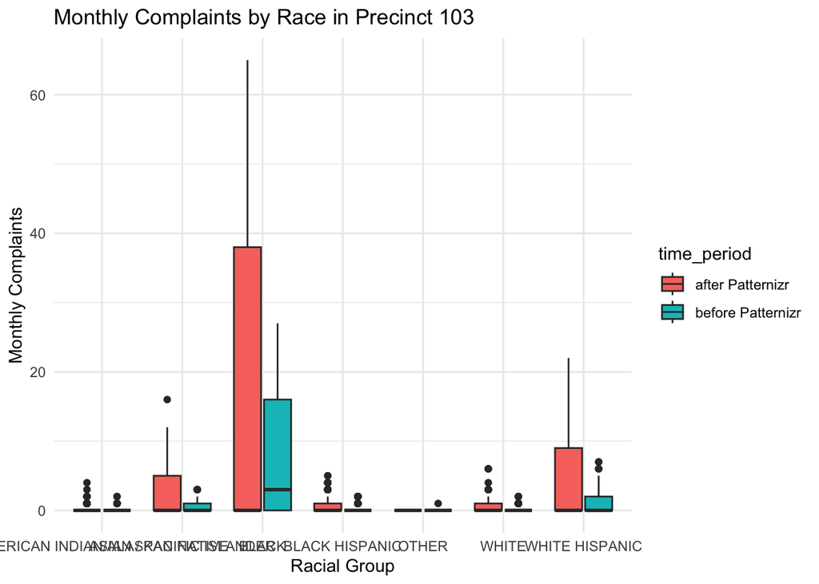

```r
#VISUALIZATION
library(ggplot2)

ggplot(p103_monthly_counts, aes(x = susp_race, y = n_complaints, fill = time_period)) +
  geom_boxplot() +
  labs(title = "Monthly Complaints by Race in Precinct 103",
       x = "Racial Group",
       y = "Monthly Complaints") +
  theme_minimal()
```

We need to check to see whether the assumptions of the standard ANOVA are violated before we trust and interpret these results. ANOVA assumes that the means are equal in variance and normally distributed.

```r
#CHECK ASSUMPTIONS
library(car)
library(ggplot2)

#extract residuals from the standard anvova model
model_residuals <- residuals(anova_model)
fitted_values <- fitted(anova_model)

#check normality assumption
shapiro.test(model_residuals) #p-value less than 0.05 means it is NOT normal
```

```
    Shapiro-Wilk normality test

data:  model_residuals
W = 0.64717, p-value < 2.2e-16
```

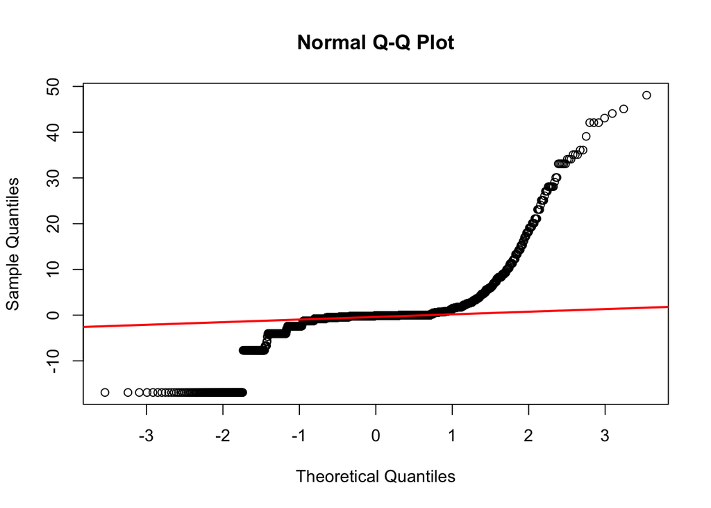

```r
qqnorm(model_residuals)
qqline(model_residuals, col = "red", lwd = 2)
```

```r
#check equal variance between groups assumption
leveneTest(n_complaints ~ susp_race * time_period, data = p103_monthly_counts) #p-value less than 0.05 means they are NOT equal
```

```
Levene's Test for Homogeneity of Variance (center = median)
        Df F value    Pr(>F)
group   13  99.218 < 2.2e-16 ***
      2520
---
Signif. codes:  0 '***' 0.001 '**' 0.01 '*' 0.05 '.' 0.1 ' ' 1
```

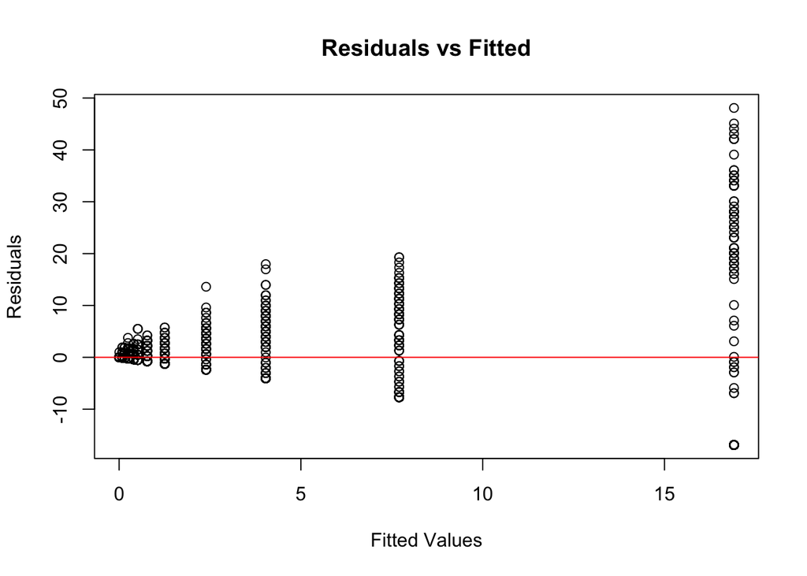

```r
plot(fitted_values, model_residuals,
     main = "Residuals vs Fitted", xlab = "Fitted Values", ylab = "Residuals")
abline(h = 0, col = "red")
```

Assumptions of normality and variance are both violated for the precinct above. So we will use a non-parametric version of ANOVA, the Algined Rank Transform method.

```r
library(ARTool)

#run non-parametric ANOVA given that both normality and equal variance assumptions are violated
art_model <- art(n_complaints ~ susp_race * time_period, data = p103_monthly_counts)

# Get the results
art_results <- anova(art_model)
art_results
```

```
Analysis of Variance of Aligned Rank Transformed Data

Table Type: Anova Table (Type III tests)
Model: No Repeated Measures (lm)
Response: art(n_complaints)

                        Df Df.res F value     Pr(>F)
1 susp_race              6   2520  85.233 < 2.22e-16 ***
2 time_period            1   2520 560.480 < 2.22e-16 ***
3 susp_race:time_period  6   2520  38.313 < 2.22e-16 ***
---
Signif. codes:   0 '***' 0.001 '**' 0.01 '*' 0.05 '.' 0.1 ' ' 1
```

For precinct 103, the average monthly complaints differs by suspect’s racial group and the time period. We can see that there is a statistically significant interaction effect as well meaning that the average monthly complaints different by suspect’s racial group AND time period together.

Now, we need to repeat this analysis for 20 more precincts. To do this, we will create a function and apply it to all precincts of interest.

```r
library(tidyverse)
library(lubridate)
library(car)
library(ARTool)

anova_analysis <- function(precinct_id, full_df) {

  # A. DATA PREPARATION ----------------------------------------------
  # Filter for the specific precinct
  pct_data <- full_df |>
    filter(precinct_crime == precinct_id)

  # Aggregate to Monthly Counts (inc. filling zeros)
  pct_monthly <- pct_data |>
    mutate(month = floor_date(complaint_date, "month")) |>
    count(susp_race, time_period, month) |>
    ungroup() |>
    complete(susp_race, time_period, month, fill = list(n = 0)) |>
    rename(n_complaints = n) |>
    mutate(
      susp_race = factor(susp_race),
      time_period = factor(time_period)
    )

  # --- SAFETY CHECK: CRITICAL FIX ---
  # Check if we have enough levels to compare (Need at least 2 races AND 2 periods)
  if (nlevels(pct_monthly$susp_race) < 2 || nlevels(pct_monthly$time_period) < 2) {
    message(paste("Skipping Precinct", precinct_id, "- Not enough factor levels."))
    return(NULL)
  }

  # Check if variance exists (cannot analyze if all counts are exactly 0 or constant)
  if (var(pct_monthly$n_complaints) == 0) {
    message(paste("Skipping Precinct", precinct_id, "- No variance in complaints."))
    return(NULL)
  }
  # ----------------------------------

  # B. VISUALIZATION -------------------------------------------------
  # Create the boxplot and save it to a variable
  p_plot <- ggplot(pct_monthly, aes(x = susp_race, y = n_complaints, fill = time_period)) +
    geom_boxplot() +
    labs(title = paste("Precinct", precinct_id, "- Monthly Complaints"),
         x = "Racial Group", y = "Count") +
    theme_minimal() +
    theme(axis.text.x = element_text(angle = 45, hjust = 1))


  # C. ASSUMPTION CHECKING (AUTOMATED) -------------------------------
  # Run standard ANOVA just to get residuals for testing
  std_model <- aov(n_complaints ~ susp_race * time_period, data = pct_monthly)
  resids <- residuals(std_model)

  # Run tests and save p-values (Normal if > 0.05, Homogeneous if > 0.05)
  shapiro <- shapiro.test(resids)$p.value
  levene  <- leveneTest(n_complaints ~ susp_race * time_period, data = pct_monthly)$`Pr(>F)`[1]

  assumptions <- data.frame(
    precinct_crime = precinct_id,
    Shapiro_P = round(shapiro, 4),
    Levene_P = round(levene, 4),
    Normal = ifelse(shapiro > 0.05, "Yes", "No"),
    EqualVar = ifelse(levene > 0.05, "Yes", "No")
  )

  # D. ROBUST ANOVA (ARTool) -----------------------------------------
  if (shapiro < 0.05 | levene < 0.05){
    art_model <- art(n_complaints ~ susp_race * time_period, data = pct_monthly)
    art_results <- anova(art_model)

    art_df <- as.data.frame(art_results)
    art_df$precinct_crime <- precinct_id #add precinct_id column
  }
  #this would fail if any of the assumptions were not violated BUT shouldn't since all top 20 precincts dfs assumptions are violated


  # E. RETURN EVERYTHING ---------------------------------------------
  # Return a list containing all the pieces
  return(list(
    precinct_crime = precinct_id,
    boxplot = p_plot,
    assumptions_df = assumptions,
    art_df = art_df,
    art_model = art_model
  ))
}
```

```r
#Apply the function to all precincts

# 1. Define your list of precincts
#top_20_precincts
#top10_precincts_chisq <- c(103, 113, 73, 81, 83, 71, 105, 79, 41) #may as well apply to all top 20 precincts

# 2. Run the function on all precincts
# This stores all results in a master list
all_anova_results <- lapply(top_20_precincts$precinct_crime, function(x) {
  anova_analysis(precinct_id = x, full_df = race_df)
})

# 3. Name the list items for easy access
names(all_anova_results) <- as.character(top_20_precincts$precinct_crime)
#print(all_anova_results)
```

The above variable (all_anova_results) contains the list of results from the function, including assumptions_df, art_df, and art_model. Now we need to look at just the art_df to be able to interpret the results.

```r
#Extarct only the ART/ANOVA results
# 1. Extract just the 'art_df' table from every precinct in the list
# This creates a list of dataframes (ignoring the plots and assumption tables)
list_of_art_tables <- lapply(all_anova_results, function(x) x$art_df)

# 2. Bind them all into one giant dataframe
all_art_tables_df <- bind_rows(list_of_art_tables)

# 3. View the final result
print(all_art_tables_df)
```

```
                                            Term Df Df.res    Sum Sq Sum Sq.res
susp_race...1                          susp_race  5   2376 115751911  717782658
time_period...2                      time_period  1   2376 153404516  830658920
susp_race:time_period...3  susp_race:time_period  5   2376  49976903  899239417
susp_race...4                          susp_race  5   2328 119203937  676844359
time_period...5                      time_period  1   2328  61824430  883591316
susp_race:time_period...6  susp_race:time_period  5   2328  41599591  892449190
susp_race...7                          susp_race  5   2256 124179146  560535815
time_period...8                      time_period  1   2256  78462240  721110242
susp_race:time_period...9  susp_race:time_period  5   2256  76602466  706094104
susp_race...10                         susp_race  5   2244  91082140  534000450
time_period...11                     time_period  1   2244 316139474  514535987
susp_race:time_period...12 susp_race:time_period  5   2244  57526503  567519718
susp_race...13                         susp_race  5   2196 122025539  533448192
time_period...14                     time_period  1   2196  64281945  717541574
susp_race:time_period...15 susp_race:time_period  5   2196  58410785  719617537
susp_race...16                         susp_race  5   2244 113672754  555208191
time_period...17                     time_period  1   2244 192007677  622789255
susp_race:time_period...18 susp_race:time_period  5   2244  44264809  659737888
susp_race...19                         susp_race  5   2196 113290125  544001703
time_period...20                     time_period  1   2196 172851934  599821107
susp_race:time_period...21 susp_race:time_period  5   2196  58942166  640650099
susp_race...22                         susp_race  5   2196 115887279  576554194
time_period...23                     time_period  1   2196  52577664  739477915
susp_race:time_period...24 susp_race:time_period  5   2196  39016647  767330698
susp_race...25                         susp_race  5   2268 122900498  595378105
time_period...26                     time_period  1   2268  59632374  799241319
susp_race:time_period...27 susp_race:time_period  5   2268  53497952  811246099
susp_race...28                         susp_race  4   1840  52711398  352231114
time_period...29                     time_period  1   1840  59156696  405614053
susp_race:time_period...30 susp_race:time_period  4   1840  14209289  441479768
susp_race...31                         susp_race  5   2172 117362658  525422137
time_period...32                     time_period  1   2172  61148955  708727128
susp_race:time_period...33 susp_race:time_period  5   2172  51555395  722474607
susp_race...34                         susp_race  6   2520 166982384  822831542
time_period...35                     time_period  1   2520 206978875  930607573
susp_race:time_period...36 susp_race:time_period  6   2520  91373573 1001665909
susp_race...37                         susp_race  5   2148 119846538  496633533
time_period...38                     time_period  1   2148  92033761  637064427
susp_race:time_period...39 susp_race:time_period  5   2148  80693348  619507493
```

[output cut: 67 more lines]

```
susp_race...46               69.85881  2.878357e-68             83
time_period...47             37.32455  1.167977e-09             83
susp_race:time_period...48   10.62506  4.131420e-10             83
susp_race...49               60.56277  2.676270e-59            105
time_period...50            697.26306 7.375268e-134            105
susp_race:time_period...51   16.75517  2.784179e-16            105
susp_race...52               57.57190  1.499196e-56            115
time_period...53            367.71789  4.191872e-76            115
susp_race:time_period...54   17.53152  4.488400e-17            115
susp_race...55               57.06359  6.921258e-56            114
time_period...56             71.22753  5.746473e-17            114
susp_race:time_period...57   11.23566  1.030699e-10            114
susp_race...58               85.38117  5.534568e-82             81
time_period...59            632.68742 1.669270e-122             81
susp_race:time_period...60   24.48704  4.778618e-24             81
```

```r
# Optional: Export to CSV
# write_csv(giant_anova_df, "all_precincts_anova_results.csv")
```

We can see from the analysis that in every precinct, both the independent factors and their interaction have a statistically significant effect on the monthly average of complaints. Now we conduct a post-hoc test to determine which of those racial groups and time periods drove this difference in monthly average of complaints. Since we need to do this for all 20 precincts, let’s write a function to apply to all individual precinct data.

```r
library(emmeans)
library(dplyr)

# DEFINE THE FUNCTION
run_posthoc_analysis <- function(precinct_result) {

  # 1. Extract the model and ID from your previous results list
  # Note: This requires that you included 'art_model' in the return list of your previous function!
  model <- precinct_result$art_model
  precinct_id <- precinct_result$precinct_crime

  # Safety Check: If the model is NULL (precinct was skipped), return NULL
  if (is.null(model)) {
    return(NULL)
  }

  # --- STEP 1: THE FIX --------------------------------------------
  # Extract the specific linear model for the Interaction term ("susp_race:time_period").
  # 'emmeans' knows exactly how to handle this 'linear_model' object.
  linear_model <- artlm(model, "susp_race:time_period")

  # --- STEP 2: RUN EMMEANS ON THE EXTRACTED MODEL -----------------
  # Now we pass 'linear_model' instead of 'model'
  # We use the formula ~ susp_race | time_period to "slice" by time
  emm <- emmeans(linear_model, ~ susp_race | time_period)

  # --- STEP 3: RUN CONTRASTS --------------------------------------
  # 3. Run Pairwise Contrasts (The "Slicing")
  # by = "time_period": Ensures we compare races ONLY within the same era
  # (e.g. Black vs White in "After", not Black-After vs White-Before)
  contrasts <- contrast(emm, method = "pairwise", adjust = "tukey")

  # 4. Clean up the results
  # summary(..., infer = TRUE) adds p-values
  contrasts_df <- summary(contrasts, infer = TRUE) |>
    as.data.frame() |>

    # Filter to look ONLY at "After Patternizr" (Your specific interest)
    #filter(time_period == "after Patternizr") |>

    # Add Precinct ID for tracking
    mutate(precinct_crime = precinct_id) |>
    relocate(precinct_crime)

  return(contrasts_df)
}
```

Note that in the above function, we extract the linear model of the interaction effect only from the ART result because ART has 3 different versions of results based on whether you want to look at race, time period or their interaction. In other words, ART contains a separate linear model for the main effects (race, time period) and their interaction effect. Since we saw from the previous results that everything is statistically significant, we are most interested now in looking at the interaction effect. In fact, if we looked at just the main effects - according to the results of the ART analysis - we may be missing a more nuanced effect from the interaction of the main effects. Doing so will help us understand whether race AND time period have an effect on monthly average complaints. An interesting finding here would be something like: for precinct 103, being Black after Patternizr drove the most monthly average complaints.

```r
# APPLY THE FUNCTION
# Assuming 'all_anova_results' is the list you created in the previous step
posthoc_list <- lapply(all_anova_results, run_posthoc_analysis)
print(posthoc_list)
```

```
$`75`
   precinct_crime                                                      contrast
1              75 (AMERICAN INDIAN/ALASKAN NATIVE) - (ASIAN / PACIFIC ISLANDER)
2              75                      (AMERICAN INDIAN/ALASKAN NATIVE) - BLACK
3              75             (AMERICAN INDIAN/ALASKAN NATIVE) - BLACK HISPANIC
4              75                      (AMERICAN INDIAN/ALASKAN NATIVE) - WHITE
5              75             (AMERICAN INDIAN/ALASKAN NATIVE) - WHITE HISPANIC
6              75                            (ASIAN / PACIFIC ISLANDER) - BLACK
7              75                   (ASIAN / PACIFIC ISLANDER) - BLACK HISPANIC
8              75                            (ASIAN / PACIFIC ISLANDER) - WHITE
9              75                   (ASIAN / PACIFIC ISLANDER) - WHITE HISPANIC
10             75                                        BLACK - BLACK HISPANIC
11             75                                                 BLACK - WHITE
12             75                                        BLACK - WHITE HISPANIC
13             75                                        BLACK HISPANIC - WHITE
```

[output cut: 1869 more lines]

```r
# COMBINE INTO ONE DATAFRAME
final_posthoc_df <- bind_rows(posthoc_list)
final_posthoc_df #600
```

```
    precinct_crime
1               75
2               75
3               75
4               75
5               75
6               75
7               75
8               75
9               75
10              75
11              75
12              75
13              75
14              75
```

[output cut: 2397 more lines]

```r
# VIEW ONLY SIGNIFICANT RESULTS
# This answers: "In which precincts are the racial gaps statistically significant?"
significant_gaps <- final_posthoc_df |>
  filter(p.value < 0.05) |>
  arrange(precinct_crime, p.value)

print(significant_gaps) #only 262 are significant!!!!
```

```
    precinct_crime
1               40
2               40
3               40
4               40
5               40
6               40
7               40
8               40
9               40
10              40
11              40
12              40
13              40
14              40
```

[output cut: 1037 more lines]

```r
(significant_gaps |> filter(time_period == "after Patternizr"))
```

```
   precinct_crime                                          contrast
1              40                            BLACK HISPANIC - WHITE
2              40       (ASIAN / PACIFIC ISLANDER) - BLACK HISPANIC
3              40          (AMERICAN INDIAN/ALASKAN NATIVE) - WHITE
4              40                            BLACK - BLACK HISPANIC
5              41                            WHITE - WHITE HISPANIC
6              41       (ASIAN / PACIFIC ISLANDER) - WHITE HISPANIC
7              41                            BLACK HISPANIC - WHITE
8              41          (AMERICAN INDIAN/ALASKAN NATIVE) - WHITE
9              42                            WHITE - WHITE HISPANIC
10             42          (AMERICAN INDIAN/ALASKAN NATIVE) - WHITE
11             42                            BLACK HISPANIC - WHITE
12             42                                     BLACK - WHITE
13             44          (AMERICAN INDIAN/ALASKAN NATIVE) - WHITE
14             44                            BLACK HISPANIC - WHITE
```

[output cut: 102 more lines]

# ANOVA

The chi square test tells us whether racial groups and time periods (both independently and as an interaction). From those results, we can see the magnitude of how different the count of one race was before vs. after Patternizr. Those results told us that for all but 2 of the top 20 precincts, there was a statistically significant increase in the distribution of racial groups before vs. after Patternizr. The residuals tell us precisely how different the conunt of each racial group was before vs. after Patternizr.

ANOVA tests whether there is a statistically significant difference in some continuous variable depending some categorical variables with 2+ groups. In our case, we are going to use two-way ANOVA to determine whether there is a statistically significant difference in monthly average arrests depending on racial group and/or time period.

For example in precinct 103, we’re looking at at least 3 different races (let’s say: Black, White, Asian) and 2 different time periods (before and after Patternizr). Now we want to conduct a statistical test to see whether the average monthly arrests differs by racial group independently, time period independently, AND racial group and time period together (interaction effect). In the actual data, there may be different numbers of racial groups represented, however we will always have two time periods of before and after Patternizr.

It would be interesting to see something like this: Black suspects are complained about the most on a monthly average basis; after Patternizr there were more complaints per month; and if you’re Black and it’s after Patternizr, there is a statistically significant chance you will be disproportionately complained about to police.

*Did Fareeza analyze different precincts in chi square after re-upload?* Jackson completed two-way ANOVA on every single precinct or all 20 precincts as a whole? *Why using mixed linear model? What is that?